# Lab #5 - Two-sample Data Analysis in `R`

$~$

## Onboarding

Two-sample data are generally recorded in a data frame with a binary categorical variable defining the groups and a second variable defining the outcome, which can be either categorical or quantitative.

Before starting this lab we will cover a few *data manipulation* techniques that are helpful in getting more complex data to fit within this framework. To do so, we will use a few functions from the `dplyr` library, which you might need to install.

```r
# install.packages('dplyr')
library(dplyr)
```

### Filtering

We’ve previously seen the “TSA claims” data set, a random sample of $n=5000$ claims made against the TSA during its first five years of existence. The data set uses 16 categories to group the items involved in claims:

```r
tsa_data = read.csv("https://remiller1450.github.io/data/tsa_small.csv")
table(tsa_data$Item)
```

```
##
##                                            Cameras - Digital
##                                                          440
##                                                  Cell Phones
##                                                           55
##                   Clothing - Shoes; belts; accessories; etc.
##                                                          578
##                                            Computer - Laptop
##                                                          242
## Cosmetics - Perfume; toilet articles; medicines; soaps; etc.
##                                                          100
##                                                     Currency
##                                                           93
##                                               DVD/CD Players
##                                                           50
##                      Eyeglasses - (including contact lenses)
##                                                          114
##                                               Jewelry - Fine
##                                                          466
##                                                        Locks
##                                                          367
##                    Luggage (all types including footlockers)
##                                                          758
##                                                    Medicines
##                                                           56
##                      Musical Instruments - Other - Over $250
##                                                           26
##                                                        Other
##                                                         1581
##                               PDA - Personal Data Assistants
##                                                           27
##                                   Stereo Items & Accessories
##                                                           47
```

We might ask a research question that seeks to compare two of these 16 categories, for example digital cameras and laptops. Such a question requires us to *filter* the data set to remove any cases not belonging to the relevant categories.

```r
## Store filtered results
tsa_laptop_camera_subset = filter(tsa_data, Item %in% c("Cameras - Digital", "Computer - Laptop"))

## Display table of filtered results to confirm
table(tsa_laptop_camera_subset$Item)
```

```
##
## Cameras - Digital Computer - Laptop
##               440               242
```

You should note:

1. There is a `filter()` function in base `R` that gets masked when you load the `dplyr` package. So if you’re getting an unexpected error you should make sure you’ve run `library(dplyr)` before trying to filter.
2. The second argument in filter (after providing the data) is a *logical condition* used to determine which rows are kept. Here the condition checks if the row has a value of `Item` in the list `c("Cameras - Digital", "Computer - Laptop")`, and the rows that have such an item are kept.

$~$

### Grouped Summarization

After filtering we might want to calculate descriptive statistics separately for each group. We can do this by stringing together a series of functions using *piping*:

```r
tsa_laptop_camera_subset %>%     ## Step 1 - provide the data
  group_by(Item) %>%             ## Step 2 - variable defining groups
  summarize(mean(Claim_Amount),  ## Step 3 - summarize
            median(Claim_Amount))
```

```
## # A tibble: 2 × 3
##   Item              `mean(Claim_Amount)` `median(Claim_Amount)`
##   <chr>                            <dbl>                  <dbl>
## 1 Cameras - Digital                 596.                   430.
## 2 Computer - Laptop                1742.                  1500
```

Piping takes the object produced by a function and passes it directly as the “data” to the next step in the chain. We could have done our filtering step as part of this pipeline if we’d wanted:

```r
tsa_data %>%                                                               ## Step 1 - provide the data
  filter(Item %in% c("Cameras - Digital", "Computer - Laptop")) %>%        ## Step 2 - filter to keep only cameras and laptops
  group_by(Item) %>%                                                       ## Step 3 - define the groups
  summarize(mean(Claim_Amount),                                            ## Step 4 - summarize
            median(Claim_Amount))
```

```
## # A tibble: 2 × 3
##   Item              `mean(Claim_Amount)` `median(Claim_Amount)`
##   <chr>                            <dbl>                  <dbl>
## 1 Cameras - Digital                 596.                   430.
## 2 Computer - Laptop                1742.                  1500
```

$~$

### Category Collapsing

```r
## Add new variable to the subset from earlier
tsa_laptop_camera_subset$Rejected = ifelse(tsa_laptop_camera_subset$Status == "Denied", "Rejected", "Not Rejected")

## Look at two-way frequency table
table(tsa_laptop_camera_subset$Item, tsa_laptop_camera_subset$Rejected)
```

```
##
##                     Not Rejected Rejected
##   Cameras - Digital          232      208
##   Computer - Laptop           95      147
```

The first argument given to `ifelse()` is a logical check, the second is the outcome that is returned for cases where that check evaluates to `TRUE`, and the third is the value returned for cases where that the check evaluates to `FALSE`. In this example we can see that all rows whose status was `"Denied"` were mapped to `"Rejected"`, while the other statuses (settled and approved) were mapped to `"Not Rejected"`.

$~$

## Lab

### Two-sample Categorical Data

A thorough data analysis generally involves data visualizations, descriptive statistics, and hypothesis testing. For two-sample categorical data there are three types of bar chart that we might consider using to visualize our data:

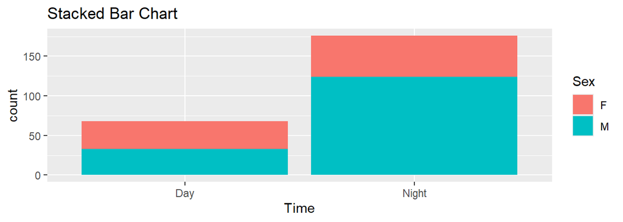

```r
## Example Data
library(ggplot2)
example_data <- read.csv("https://remiller1450.github.io/data/Tips.csv")

## Stacked
ggplot(example_data, aes(x = Time, fill = Sex)) + geom_bar(position = "stack") + labs(title = "Stacked Bar Chart")
```

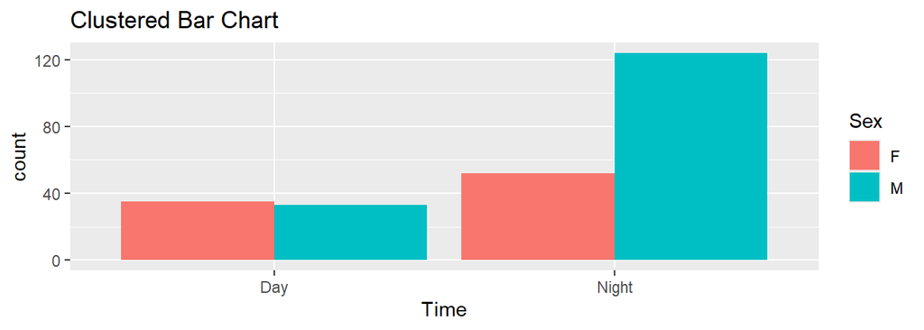

```r
## Clustered
ggplot(example_data, aes(x = Time, fill = Sex)) + geom_bar(position = "dodge") + labs(title = "Clustered Bar Chart")
```

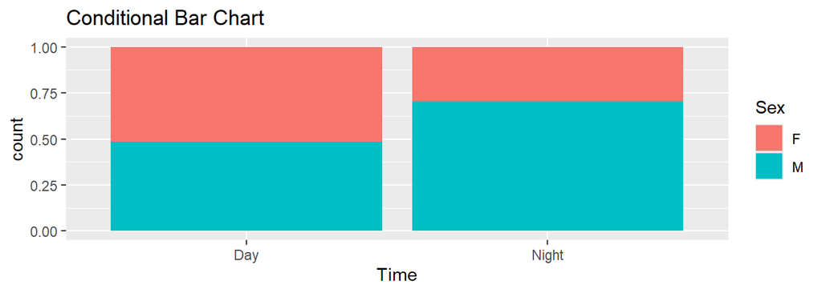

```r
## Conditional
ggplot(example_data, aes(x = Time, fill = Sex)) + geom_bar(position = "fill") + labs(title = "Conditional Bar Chart")
```

When choosing between these options, you should consider what they can/cannot show:

- Stacked and clustered bar charts communicate the sample sizes in each group, but it can be difficult to compare the proportions of each outcome
- Conditional bar charts do not communicate sample size, but they make it easier to directly compare proportions.

For two-sample categorical data, the `prop.test()` function can be used to provide both descriptive statistics and hypothesis testing results. We need to provide the numerator and denominator for both of the sample proportions involved in the *two-sample $Z$-test*. Below we can see a two-way table for the example data:

```r
## Two-way table
table(example_data$Time, example_data$Sex)
```

```
##
##           F   M
##   Day    35  33
##   Night  52 124
```

We can store this table and reference specific values using indices:

```r
example_table = table(example_data$Time, example_data$Sex)
example_table[1,1] ## Daytime tables w/ a female customer
```

```
## [1] 35
```

Values from the table can be used to obtain the numerators and denominators we need to perform the two-sample $Z$-test:

```r
num1 = example_table[1,1]
denom1 = example_table[1,1] + example_table[1,2]
num2 = example_table[2,1]
denom2 = example_table[2,1] + example_table[2,2]
```

Note that this gives *conditional proportions*, the proportion of female tables during daytime (`num1/denom1`) and the proportion of female tables at night (`num2/denom2`). We must keep track of this because `prop.test()` will only give us “p1” and “p2” using the order we provide it.

The code below shows how these quantities are used in `prop.test()` to perform the two-sample $Z$-test using the null hypothesis $H_0: p_1 = p_2$:

```r
prop.test(x = c(num1, num2), n = c(denom1, denom2), correct = FALSE)
```

```
##
##  2-sample test for equality of proportions without continuity correction
##
## data:  c(num1, num2) out of c(denom1, denom2)
## X-squared = 10.277, df = 1, p-value = 0.001347
## alternative hypothesis: two.sided
## 95 percent confidence interval:
##  0.0826709 0.3558318
## sample estimates:
##    prop 1    prop 2
## 0.5147059 0.2954545
```

In this example, a good analysis might include one of the previously displayed bar charts along with the conclusion statement:

> “There is strong evidence ($p=0.001$) that daytime tables have a higher proportion of female customers (51.47%) relative to nighttime tables (29.55%) for this individual.”

Notice how the conclusion includes context, level of evidence, and direction, and it also provides relevant descriptive statistics (conditional percentages within each group).

**Question #1**: For this question you should begin with the full TSA claims data set. You will investigate whether theft is more likely to occur at security checkpoints or with checked baggage.

- **Part A**: Follow the steps in the lab’s introduction to create a filtered subset of the data that contains only “Checked Baggage” and “Checkpoint” claim sites.
- **Part B**: Follow the steps in the lab’s introduction to create a binary outcome variable that indicates whether a claim was theft. Name the variable “Theft” and ensure that it takes on the value “theft” if the claim type was “Passenger Theft” and the value “not theft” for all other claim types.
- **Part C**: Create *both* clustered and conditional bar charts displaying the relationship between claim site and the variable “Theft” you created in Part B. Make sure that claim site, the explanatory variable, is the mapped to the `x` aesthetic in your plot. Which of these graphs do you prefer? There is no correct preference, but you should provide a reason explaining your choice.
- **Part D**: Create a two-way frequency table of the variables `Theft` and `Claim_Site` for the data subset you’ve been working with on this question.
- **Part E**: Use the frequencies from the table you created in Part D to create the required inputs to `prop.test()` and perform a two-sample $Z$-test evaluating whether the proportion of theft claims at checkpoints is the same as the proportion of theft claims involving checked baggage. Provide a one-sentence conclusion that includes the $p$-value and the conditional proportions involved in the test. See the example in this section for help on what a good conclusion might look like.

$~$

### Two-sample Quantitative Data

For two-sample quantitative data, side-by-side boxplots or histograms are appropriate data visualizations:

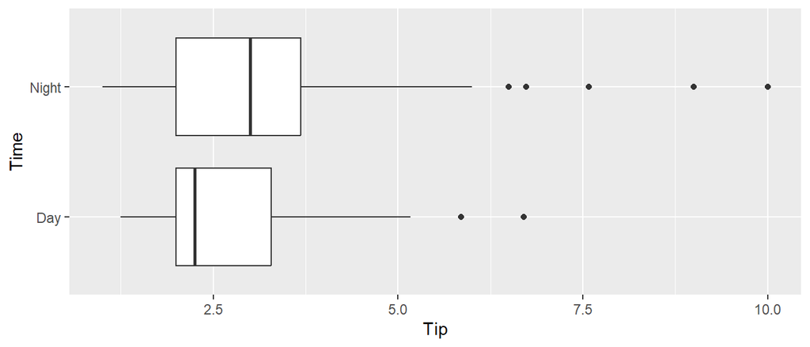

```r
## Boxplots
ggplot(example_data, aes(x = Tip, y = Time)) + geom_boxplot()
```

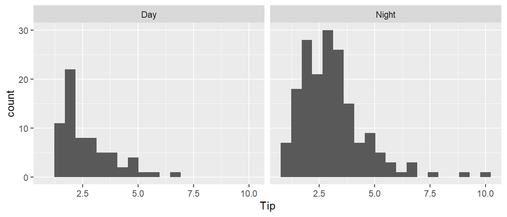

```r
## Histograms
ggplot(example_data, aes(x = Tip)) +  geom_histogram(bins = 20) + facet_wrap(~Time)
```

We’ll generally prefer boxplots, with the exception being when you’re checking the distributional shape within groups.

Descriptive statistics for two-sample quantitative data should be calculated using grouped summarization (described in the lab’s introduction). Another example of this is shown below:

```r
example_data %>%        ## Dataset
  group_by(Time) %>%    ## variable defining the groups
  summarize(mean(Tip),  ## group means
            sd(Tip),    ## group standard deviations
            n())        ## group sizes
```

```
## # A tibble: 2 × 4
##   Time  `mean(Tip)` `sd(Tip)` `n()`
##   <chr>       <dbl>     <dbl> <int>
## 1 Day          2.73      1.21    68
## 2 Night        3.10      1.44   176
```

Note that the command `n()` will simply count the number of cases in each group.

Finally, we can perform the *two-sample $T$-test* using the `t.test()` function:

```r
t.test(Tip ~ Time, data = example_data)
```

```
##
##  Welch Two Sample t-test
##
## data:  Tip by Time
## t = -2.0593, df = 144.07, p-value = 0.04126
## alternative hypothesis: true difference in means between group Day and group Night is not equal to 0
## 95 percent confidence interval:
##  -0.73411080 -0.01505364
## sample estimates:
##   mean in group Day mean in group Night
##            2.728088            3.102670
```

The syntax here is a bit different from our prior use of `t.test()`, but will be very useful to get familiar with as we move towards building regression models. The first piece, `Tip ~ Time`, is a *formula* that says that the variable “Tip” is explained by the variable “Time”. We also provide the data so that `t.test()` knows where to look for these variables.

In this example, a good analysis might include the side-by-side boxplots along with the conclusion statement:

> “There is moderate evidence ($p=0.041$) that nighttime tables have a higher average tip ($3.10) than daytime tables ($2.73) for tables served by this individual.”

**Question #2**: For this question you will use the data subset you created in Question #1 that only contains the “Checkpoint” and “Checked Baggage” claim sites.

- **Part A**: Create a set of side-by-side box plots and/or histograms showing the distribution of the variable `Close_Amount` at each claim site. How would you describe the shape of these distributions?
- **Part B**: Use grouped summarization to find the mean `Close_Amount` at each claim site.
- **Part C**: Perform a two-sample $T$-test investigating whether the average `Close_Amount` is equal at both claim sites. Provide a one-sentence conclusion that includes both the $p$-value and the average close amounts observed in each group (sample). See the example in this section for help on what a good conclusion might look like.

$~$

### Violated Assumptions

The two-sample $Z$ and $T$ tests both assume specific probability models for the outcomes of interest, but depending upon the characteristics of the sample and the population being studied these assumed models might be inappropriate. These conditions are summarized below:

- Two-sample $Z$-test - at least 10 of each outcome are expected in each group (sample), or $n_1 p_0 \geq 10$, $n_1(1-p_0) \geq 10$, $n_2 p_0 \geq 10$, and $n_2(1-p_0) \geq 10$
- Two-sample $T$-test - *either* both group sizes (samples) are large (ie: $n_1 \geq 30$ and $n_2 \geq 30$), *or* it is reasonable to assume the data came from Normally distributed populations (judged via histograms or box plots)

#### Fisher’s Exact Test

If the conditions for the two-sample $Z$-test are not met, a reasonable alternative is **Fisher’s exact test**, which tests whether the rows and columns of a two-way frequency table are independent given the table’s marginal totals are fixed. To perform Fisher’s exact test we supply the relevant two-way frequency table to the `fisher.test()` function:

```r
## Example from earlier - difference in proportion of female customers by time of day
example_table = table(example_data$Time, example_data$Sex)
fisher.test(example_table)
```

```
##
##  Fisher's Exact Test for Count Data
##
## data:  example_table
## p-value = 0.001737
## alternative hypothesis: true odds ratio is not equal to 1
## 95 percent confidence interval:
##  1.364025 4.678206
## sample estimates:
## odds ratio
##   2.518817
```

We will discuss odds ratios and what they mean later in the course, but for now you should recognize that the $p$-value is extremely close to the one we saw with `prop.test()` (0.0017 here vs. 0.0013 earlier in the lab). Because the $p$-value is so small, the conclusion is that there is strong evidence of an association between the time of day and whether the customer was female.

**Question #3**:

- **Part A**: Filter the full TSA claims data set to include only claims that involve cell phones or personal data assistants (PDA). Then use `ifelse()` to create variable named “approved” that takes on the value “approved” if a claim was approved and the value “not approved” if the claim was either settled or denied. Use the `table()` function to display a two-way frequency table involving these variables. If your data preparation steps were correct you should see a 2 by 2 table with 4 cells (counts).
- **Part B**: Using the frequency table from Part A, calculate the pooled proportion reflecting independence between the item (cell phone or PDA) and whether the claim was approved in full.
- **Part C**: Using the pooled proportion from Part B, explain why Fisher’s exact test might be more appropriate than a two-sample $Z$-test for comparing the approval rates of these two item categories.
- **Part D**: Perform Fisher’s exact test using `fisher.test()` and provide a one-sentence conclusion that includes the $p$-value.
- **Part E**: Use `prop.test()` to address the same hypotheses involved in Parts C and D. How does this $p$-value compare to the one from Part D?

$~$

#### Wilcoxon Rank-Sum Test

The Wilcoxon Rank Sum Test (also known as the Mann-Whitney U-test) is a rank-based test that does not make any distributional assumptions and can be used in situations where you might be considering the two-sample $T-test.

The null hypothesis is that both groups follow the same distribution, and the alternative is that both groups follow different distributions. The test is conducted using the following steps:

- Each data-point, regardless of group, is ranked from smallest to largest
- These ranks are summed within each group
- These two sums, along with the sample sizes in each group, are used to compute a test statistic that is compared against a null distribution to produce a $p$-value

The test is performed using the `wilcox.test()` function:

```r
## Perform the test on our example data (tips by time of day)
wilcox.test(Tip ~ Time, mu = 0, data = example_data)
```

```
##
##  Wilcoxon rank sum test with continuity correction
##
## data:  Tip by Time
## W = 4905, p-value = 0.02883
## alternative hypothesis: true location shift is not equal to 0
```

**Question #4**: In Question #3 you created a filtered version of the TSA claims data that contains only claims which involved cell phones or personal data assistants (PDA). You will continue using that subset in this question.

- **Part A**: Create side-by-side box plots of the variable “Claim_Amount” for the two categories of item included in this subset. Based upon these box plots and the number of claims made involving each type of item, assess whether the assumptions of the two-sample $T$-test seem reasonable for these data.
- **Part B**: Perform the Wilcoxon Rank-Sum test to assess whether there is statistical evidence that claim amounts differ by item for the two items involved in the data subset used in this question. Provide a one-sentence conclusion that includes the $p$-value of the test.
- **Part C**: Use `t.test()` to evaluate the hypotheses considered in Parts A and B. How does the $p$-value compare to the one found using the Wilcoxon Rank-Sum test?

$~$

### Practice (required)

For the following questions you should start with the full TSA data set. Unlike previous questions where you were guided through the steps of the analysis, these questions will require to determine the proper steps and hypothesis tests on your own. Your answer to each question should include:

1. Any `R` code used to prepare your data and perform hypothesis testing (ie: `filter()`, `ifelse()`, `t.test()`, etc.)
2. At least one data visualization that is directly related to the stated research question.
3. One sentence describing the conclusion of your hypothesis test that includes *both* the $p$-value and the observed descriptive statistics (sample means or sample proportions for each group)
4. One sentence explaining your choice of hypothesis test. Here you might reference small sample sizes and a skewed distribution, or large counts in each cell of the two-way frequency table.

**Question #5**: Following the guidelines given above, perform a statistical analysis to determine if there is a difference in the proportion of property damage and personal injury claims that are denied.

$~$

**Question #6**: Following the guidelines given above, perform a statistical analysis to determine if there is a difference in the average claim amount at the Los Angeles international airport (airport code: LAX) or Chicago O’Hare international airport (airport code: ORD)